```python
%matplotlib inline
import numpy as np
import  pandas as pd
from numpy import random
import matplotlib
import matplotlib.pyplot as plt
import scipy
from scipy import stats
import pickle
import h5py
```

```python
#higgs_df = pd.read_pickle("higgs_100000_pt_1000_1200.pkl")
#qcd_df = pd.read_pickle("qcd_100000_pt_1000_1200.pkl")
```

# Problem 1

The first problem is to look at your background distribution and determine where the 5σ sensitivity threshold is. [Hint, you've done this several times now, look back at the first few labs.]

```python
# create a fake background
size, mu = int(1e6),  100
bkgd = background = stats.poisson.rvs(size= size,mu = mu)
prob5sig = stats.norm.cdf(5)
bound = stats.poisson.ppf(prob5sig, mu)
print('5-sigma Threshold:', bound);
```

```
5-sigma Threshold: 154.0
```

# Problem 2

Inject a signal with sigma value say...8

```python
prob8sig = stats.norm.cdf(8)
bound = stats.poisson.ppf(prob8sig, mu)
print('8-sigma Threshold:', bound);
prob30sig = stats.norm.cdf(30)
bound = stats.poisson.ppf(prob30sig, mu)
print('30-sigma Threshold:', bound);
```

```
8-sigma Threshold: 190.0
30-sigma Threshold: inf
```

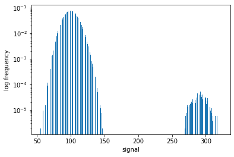

```python
# From above, I think any number is greater than or equals to 190 should be fine.
# I choose 190 to simplify the problem
bkgd = np.zeros(int(1e6))
signal = np.ones(500) * stats.poisson.isf(stats.norm.sf(8), mu = mu)
all = np.append(bkgd, signal) + stats.poisson.rvs(mu = mu, size= int(1e6) + 500)
plt.hist(all, 500, density=True)
plt.yscale('log')
plt.xlabel('signal')
plt.ylabel('log frequency')
plt.show()
```

I would say that the signal is biased. I reach this conslusion by the evidence that the real signal is around 300( or 290 according to my code). The signal I injected is 190. So it is biased.

It is symmetric.

# Problem 3

a.I simulate the data injected with different values of signal with sigma starting at 0 and goes to a number greater than 30

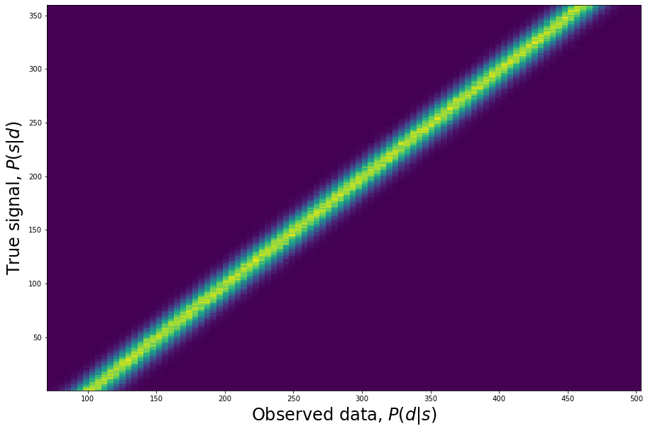

```python
# everything is the same as the code on canvas from homework
# I set the parameter to be 360 and it should be large enough
signal = stats.uniform.rvs(loc=0,scale=360, size = int(1e6))
# i set bkgd equals background to avoid my mistyping of bkgd and background
bkgd = background =stats.poisson.rvs(100,loc=0, size = int(1e6))
plt.rcParams["figure.figsize"] = (15,10)
data = bkgd + signal

signaledges = np.linspace(signal.min(),signal.max(),360)
dataedges = np.linspace(data.min(), data.max(),100)

Psd, temp, temp1= np.histogram2d(data,signal, bins=[dataedges,signaledges], density=True)

datacenters = (dataedges[:-1] + dataedges[1:]) / 2
signalcenters = (signaledges[:-1] + signaledges[1:]) / 2
plt.pcolormesh(datacenters,signalcenters,Psd.T)
plt.ylabel('True signal, $P(s|d)$', fontsize = 24)
plt.xlabel('Observed data, $P(d|s)$', fontsize = 24)
#This should get you a plot like below.
```

b. pull out the data at 190

```python
signalcenters[190]
```

```
191.03059826789232
```

not close enough in my opinion. Let's try some data around it to prove that my data is consistent with problem 2

```python
print(signalcenters[187])

print(signalcenters[188])

print(signalcenters[189])

print(signalcenters[191])

print(signalcenters[192])
```

```
188.02224415438258
189.02502885888583
190.0278135633891
192.03338297239557
193.03616767689883
```

Well, I would say that the answers are consistent.

```python
# start with a ploting function like I defined in the homework
# with some change on it
def plot_helper(sigma, type):
    fig,ax=plt.subplots(1,2,figsize=(15,10))
    if(type):ax[0].step(datacenters, Psd.T[sigma])
    else: ax[0].step(signalcenters, Psd[sigma])

    ax[0].set_xlim(200, 400)
    ax[0].set_xlabel("Signal")
    ax[0].set_ylabel("Probability")
    ax[1].pcolormesh(datacenters,signalcenters,Psd.T)
    if(type):ax[1].hlines(signalcenters[sigma], datacenters.min(), datacenters.max());
    else:ax[1].vlines(datacenters[sigma], signalcenters.min(), signalcenters.max());
    ax[1].set_ylabel('Signal, $P(s|d)$', fontsize = 24)
    ax[1].set_xlabel('Data, $P(d|s)$', fontsize = 24)
    plt.show()
```

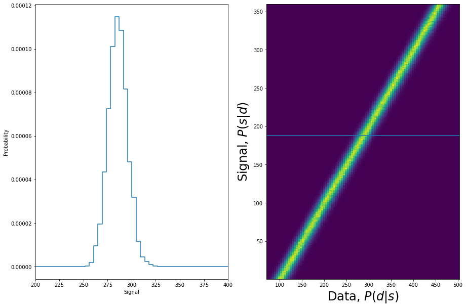

```python
plot_helper(187, True)
```

c. I choose the center of our data to be... over 5 sigma...say 82

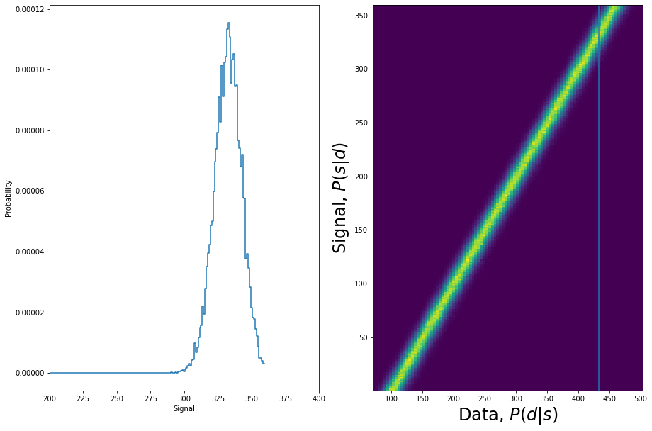

```python
plot_helper(82, False)
```

The signal is randomly chosen with requirement provided by the question. The histogram gives me the probability of detecting such as signal.

d.

```python
stats.poisson.std(100)
```

```
10.0
```

so the range is 325 plus and minus 10

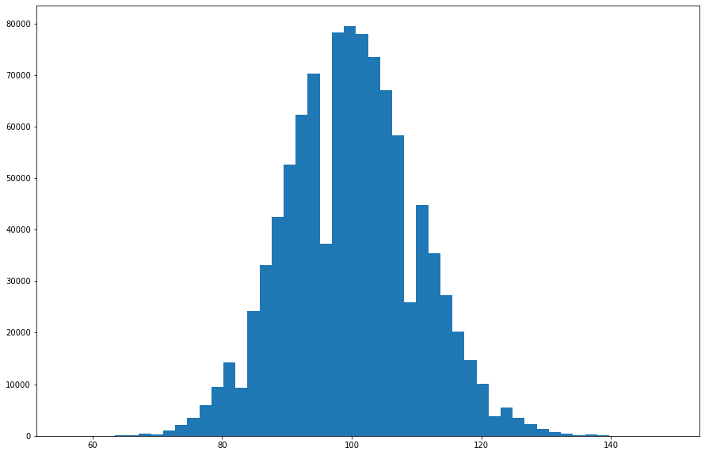

```python
bkgd = background = stats.poisson.rvs(size= size,mu = mu)
plt.hist(bkgd, 50)
```

.